# 🎓 教程：东北太平洋（FAO 67区）从零到报告

## 8. 🔍 数据质量、多样性与船队

### 8.1 数据有多可靠？`data_quality()`

```r
quality <- data_quality(area67)
```

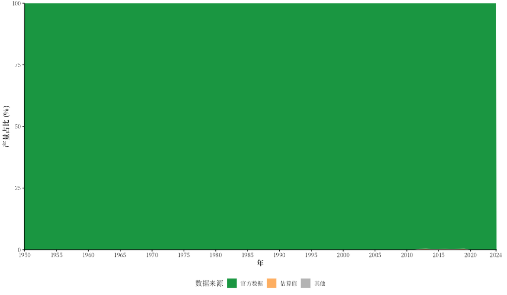

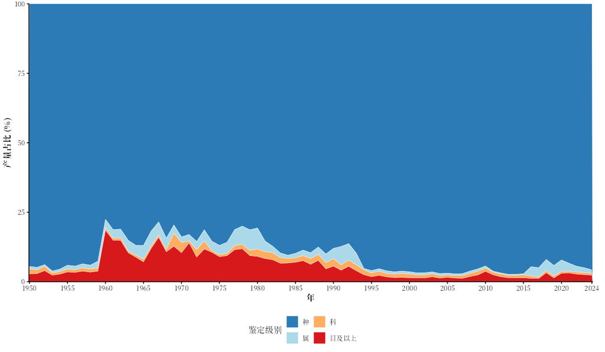

🔎 *怎么看这些图*：`_taxon_share`：鉴定到种、属、科，或只归到目及以上类群（如“Marine fishes nei”）的渔获量占比。`_status_share`：各国官方上报的渔获量占比，以及由FAO或该国估算的渔获量占比。

*67区的结果*：2024年，95.7%的渔获量鉴定到种，只有2.4%归到目或更高的类群，100.0%是各国上报的官方数据。数据这样好的渔区很少：上面的物种图描述了几乎全部渔获量，某个物种的变化不太可能是上报方式的变化。

### 8.2 多样性与集中度：`diversity_concentration()`

```r
div <- diversity_concentration(area67)
```

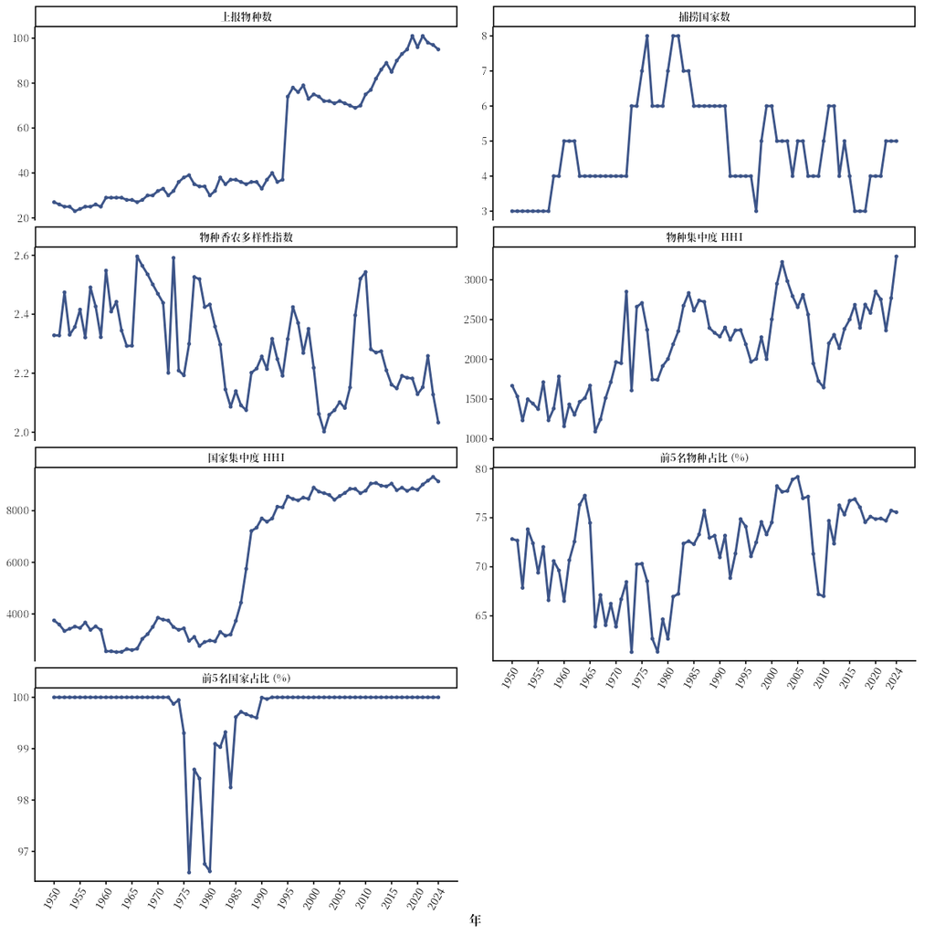

🔎 *怎么看这张图*：七个指标，每个指标一个分面：上报渔获量的物种条目数和国家数、物种的香农多样性指数、物种和国家的赫芬达尔-赫希曼指数（HHI），以及最大的五个物种和五个国家所占的份额。HHI从接近0（渔获量分散在许多物种或国家上）到10000（全部来自一个）；高于2500为“高度集中”。

*67区的结果*：2024年，有95个物种条目和5个国家上报了渔获量。两个指数都高于2500：国家的HHI为9135，接近最大值，因为几乎全部渔获都由美国捕捞；物种的HHI为3295，原因是狭鳕。该渔区物种很多，但渔获量依赖于一个国家和一个物种。

### 8.3 谁在捕捞：`country_group_summary()`和`coastal_distant()`

```r
income <- country_group_summary(area67)
fleets <- coastal_distant(area67)
```

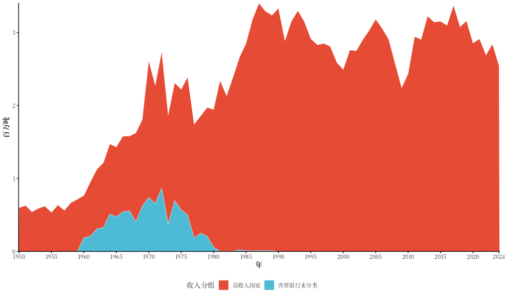

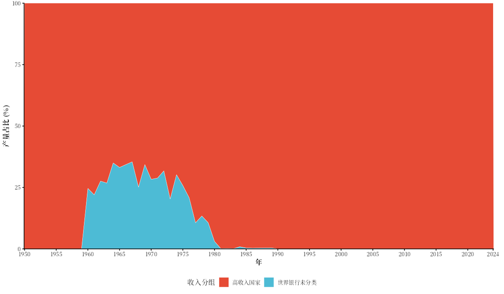

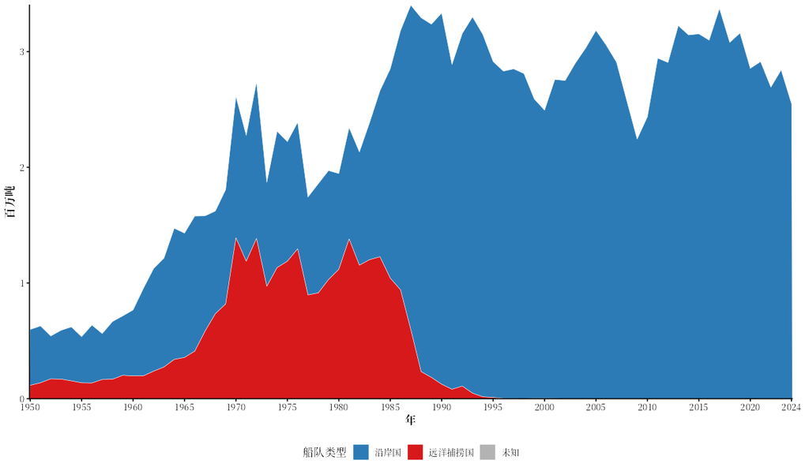

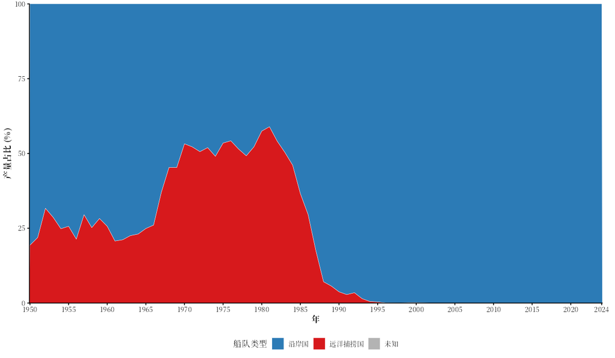

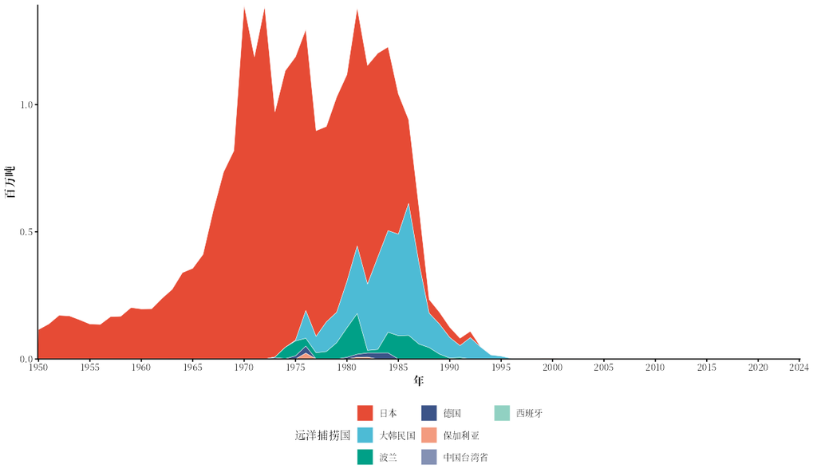

🔎 *怎么看这些图*：`country_income`：按世界银行收入分组统计的各国渔获量。`coastal_distant`：根据FAO渔区边界和国家轮廓，分为**沿岸国**（领土与该渔区接壤）和**远洋捕捞国**的渔获量。

*67区的结果*：几乎全部渔获量都由高收入国家捕捞；1960和1970年代“未分类”的部分是已不复存在的苏联。远洋捕捞国（日本、大韩民国、波兰等）1960年占渔获量的26%，1981年最高达到59%；1994年降到1%以下，此后一直如此。注意苏联和俄罗斯联邦算作沿岸国，因为俄罗斯在白令海的部分海岸与该渔区接壤：1990年以前外国船队所占的份额比远洋捕捞国的份额还要大。

## 9. 🔬 文献中的方法

这些分析采用已发表的方法；🔬 渔获骤变、渔业崩溃、同步性与远洋捕捞详细介绍了每一种方法。

### 9.1 渔获骤变：`catch_shocks()`

```r
shocks_country <- catch_shocks(area67)
shocks_species <- catch_shocks(area67, by = "species", label = "area67_species")
```

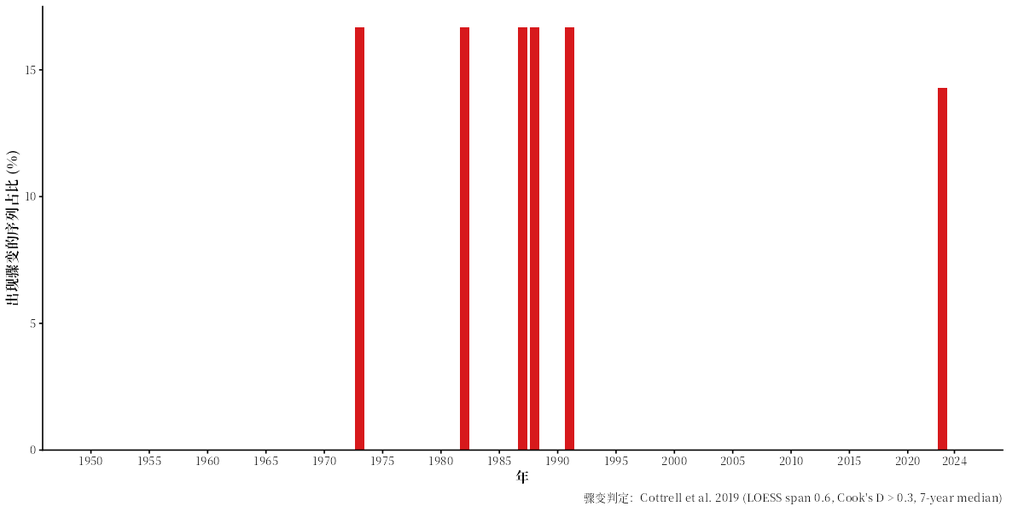

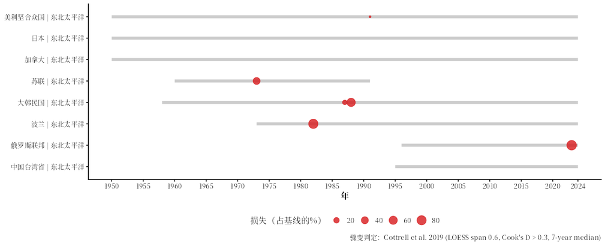

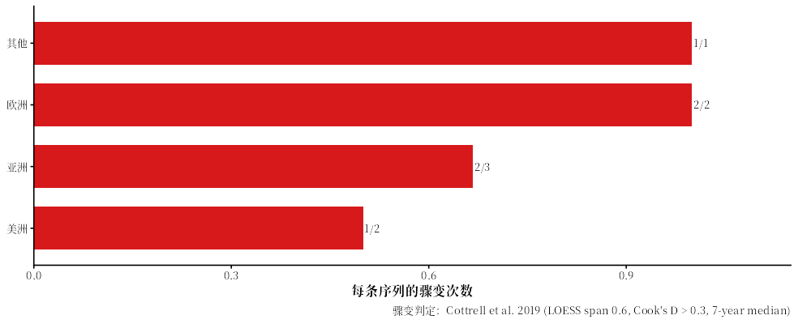

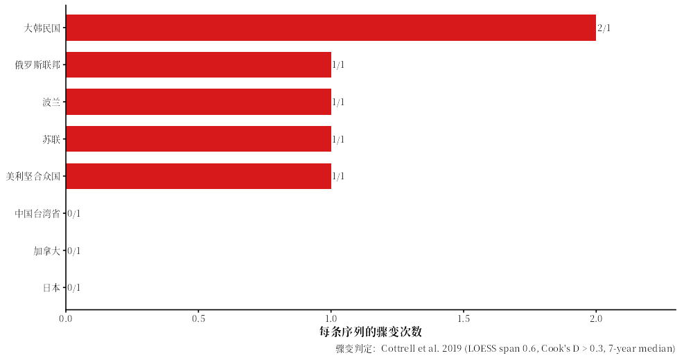

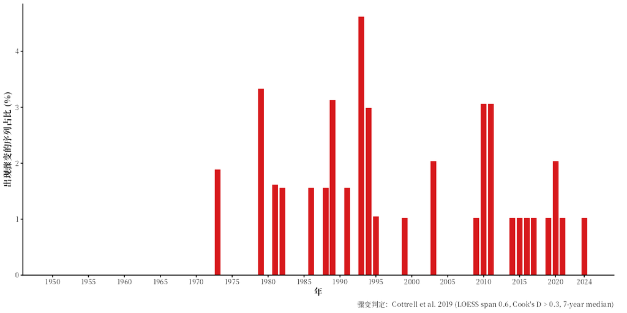

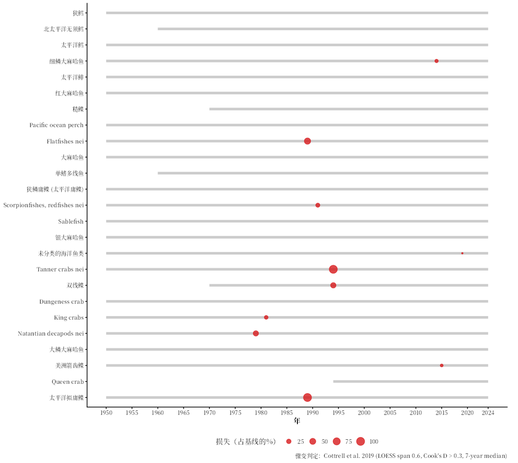

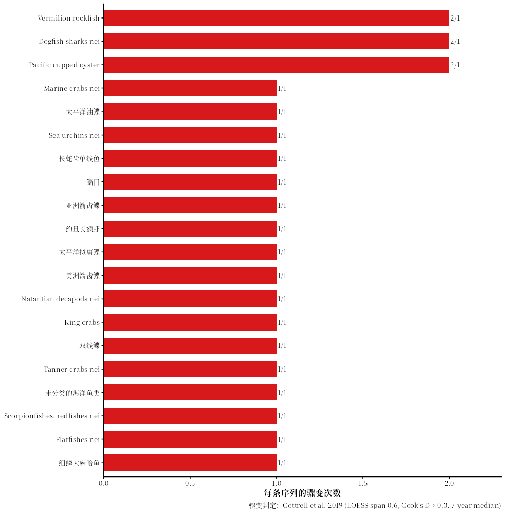

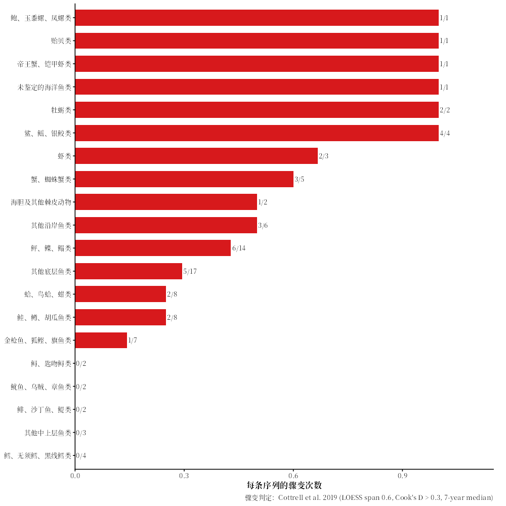

🔎 *怎么看这些图*：**骤变**是指某条序列的渔获量远低于其前几年所预示水平的年份（Cottrell等，2019）。柱状图给出每年发生骤变的序列所占的百分比；`_series`图显示各条序列及其骤变，`_by_country`和`_by_continent`图按分组统计骤变。

*67区的结果*：按国家划分序列（`by = c("country", "area")`，默认设置）时，67区只有8条序列，因此每次骤变都占很大的百分比，图很粗糙。按物种划分则有98条序列和35次骤变，对单个渔区来说信息更丰富。**按问题选择序列**：研究国家的食物供给用国家序列，研究生态用物种序列。

### 9.2 渔业崩溃：`collapse_analysis()`

```r
set.seed(1)   # 与随机序列的比较要用到随机数
collapses <- collapse_analysis(area67)
show_table(collapses$summary)
```

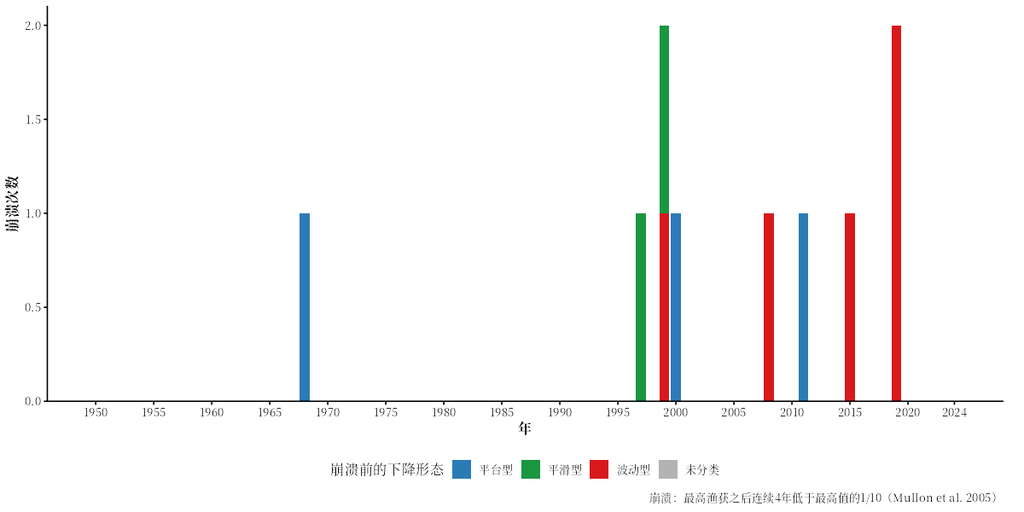

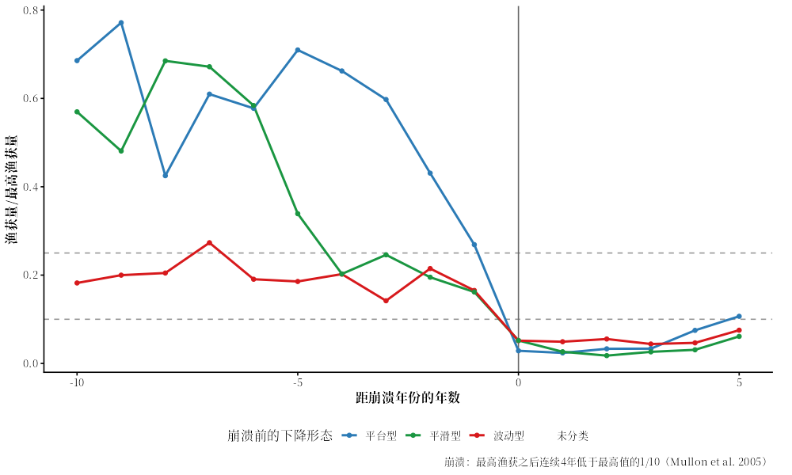

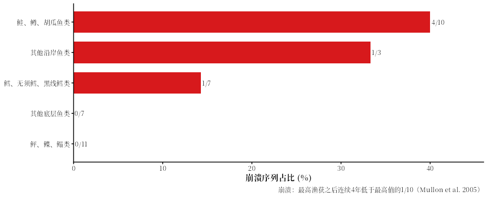

🔎 *怎么看这张图*：一条序列（一个国家捕捞的一个物种）在达到最高值之后，如果渔获量连续四年低于最高值的十分之一，即为**崩溃**（Mullon等，2005）。柱状图按年份以及崩溃前下降的形态（平台型、平滑型或波动型）统计崩溃次数。函数还会在没有趋势的随机序列上重复同样的分析，因为单是随机的涨落就会产生一些“崩溃”（Wilberg和Miller，2007）：只有超出这一零模型的部分才有意义。

*67区的结果*：50条序列中有10条崩溃（20%），而随机序列中为21%。这与单靠随机波动产生的比例相当，所以从整体上看，67区的崩溃并不能证明存在全渔区性的问题；应当逐条查看具体的序列。这正是零模型的意义所在：没有它，“20%的序列崩溃了”听起来会令人担忧。

### 9.3 同步性与组合效应：`catch_synchrony()`

```r
sync <- catch_synchrony(area67)
```

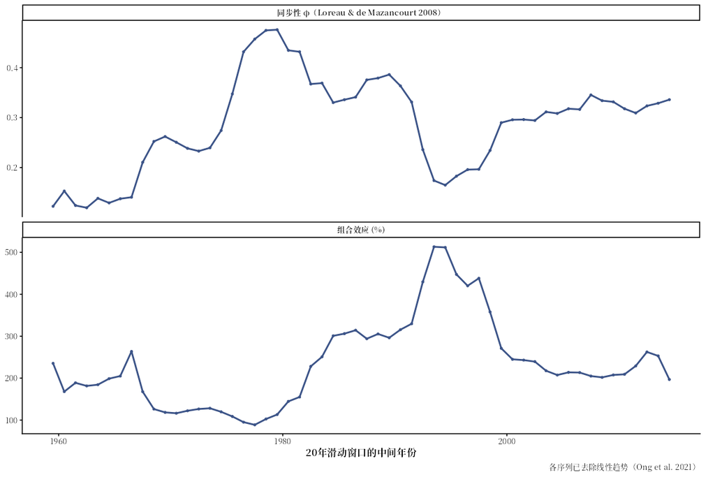

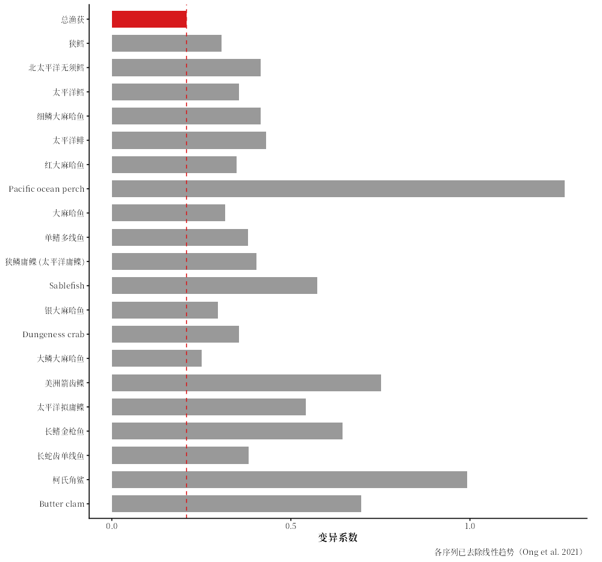

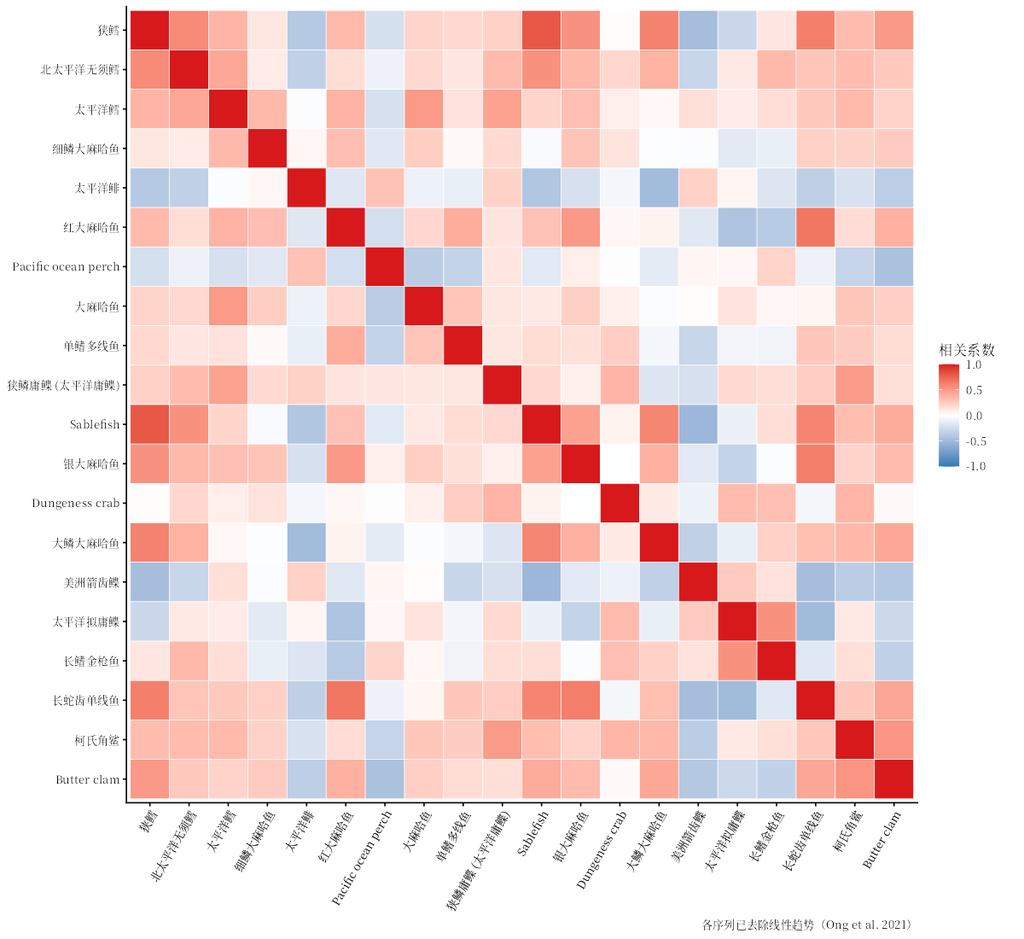

🔎 *怎么看这些图*：`_cv`：每个物种以及总渔获量（红色）的变异系数（年际波动）。`_correlation`：各物种之间如何共同变化。同步性指数φ在各物种相互补偿时为0，在同涨同落时为1（Loreau和de Mazancourt，2008）。

*67区的结果*：φ = 0.30：总渔获量的波动（变异系数0.21）远小于各物种的波动（平均变异系数0.54）：各物种的变异平均比它们的总和大161%。这种**组合效应**意味着一个物种减少时，其他物种会补上它的位置。在图中的主要物种里，Pacific ocean perch的波动远大于其他物种，这是它暴涨暴跌的痕迹。

### 9.4 中上层/底层比：`pelagic_demersal()`

```r
pd <- pelagic_demersal(area67)
show_table(pd$decades[, c("period", "pd_mean", "pd_min", "pd_max")])
```

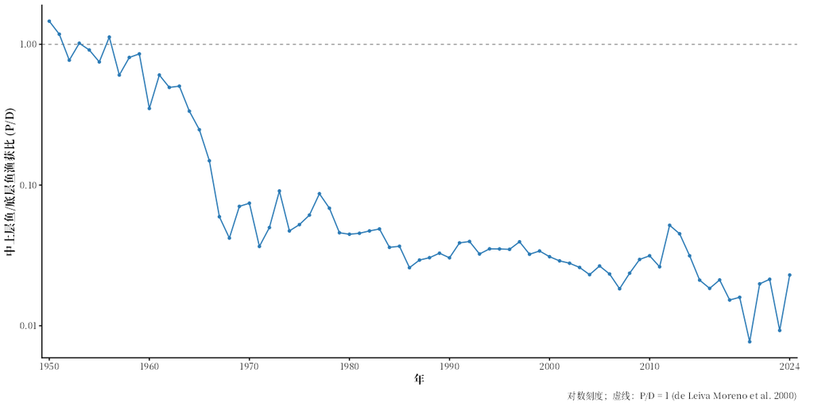

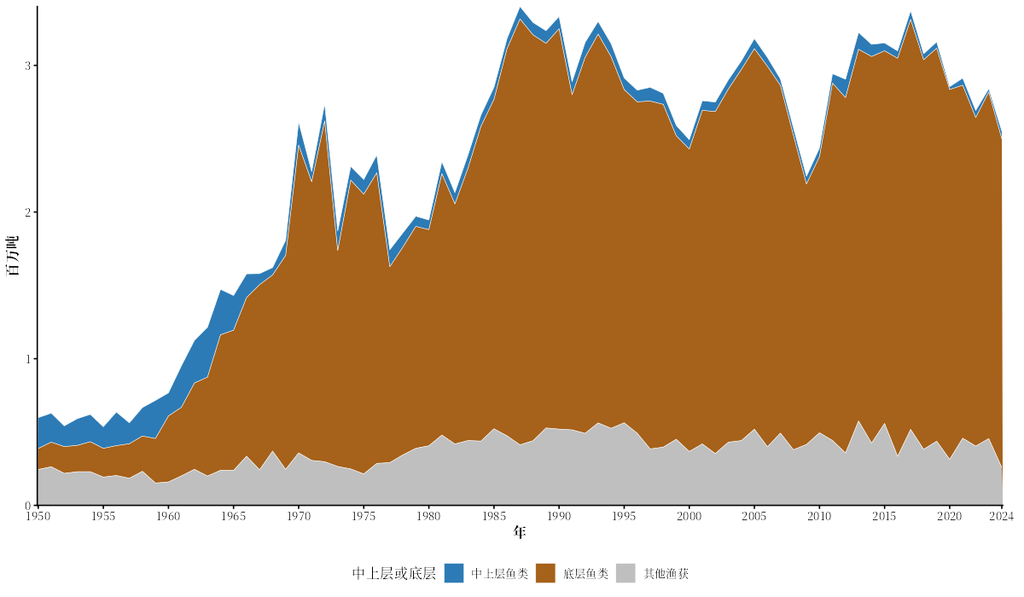

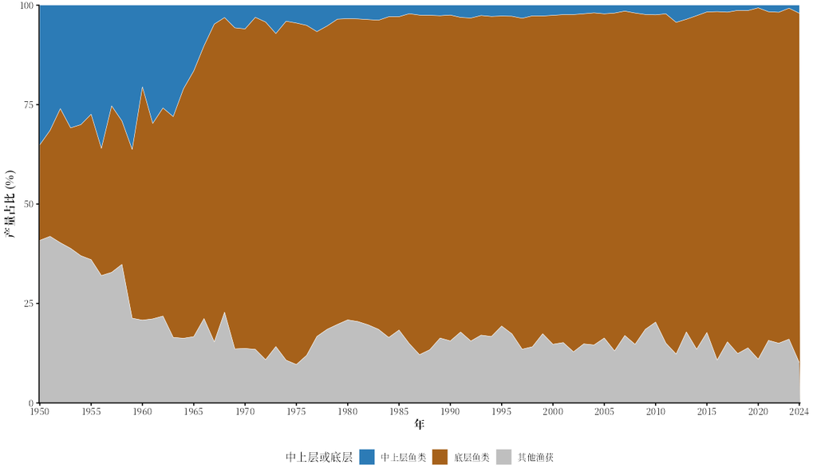

🔎 *怎么看这些图*：P/D是小型中上层鱼的渔获量除以底层鱼和甲壳类的渔获量（Caddy，1993；de Leiva Moreno等，2000），用对数坐标表示；虚线为P/D = 1。在半封闭海域，P/D上升与营养盐增加有关；在开阔海域，它主要反映船队的捕捞对象。

*67区的结果*：P/D从1950年代的0.95降到2020年代的0.016。这并不说明海里的营养盐减少了：鲱鱼渔业萎缩，而底层鱼的拖网渔业扩大，所以这个比值讲述的是渔业的历史。

### 9.5 一个远洋船队：`distant_water_profile()`

```r
japan_dw <- distant_water_profile("Japan")
```

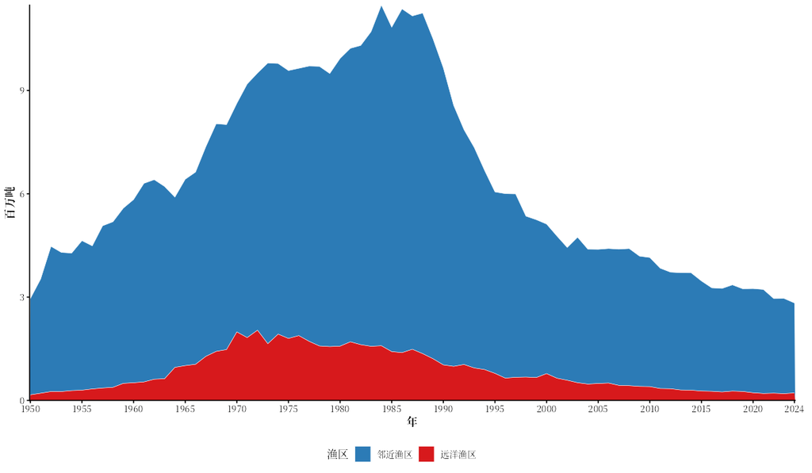

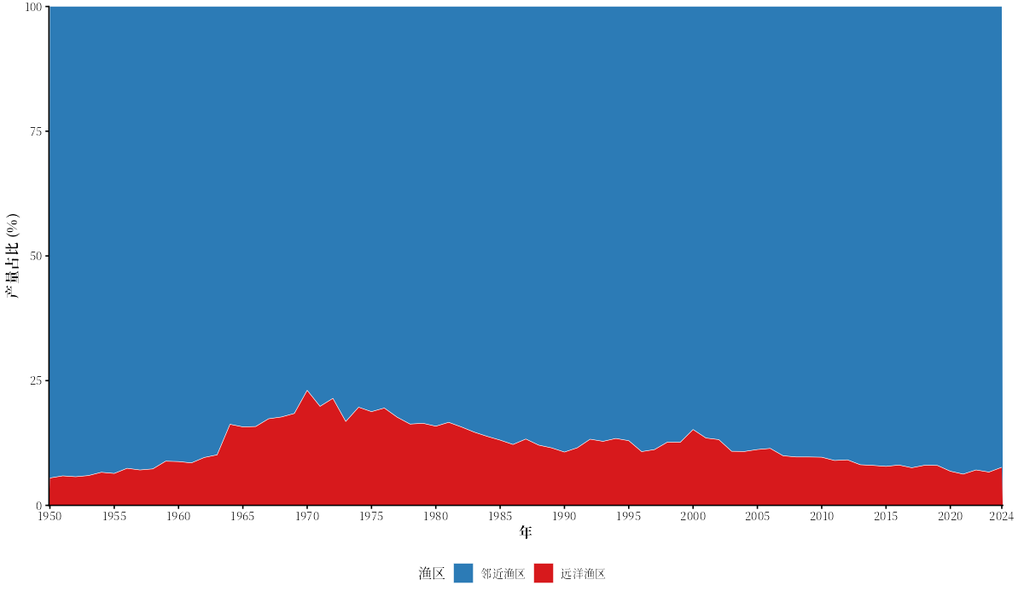

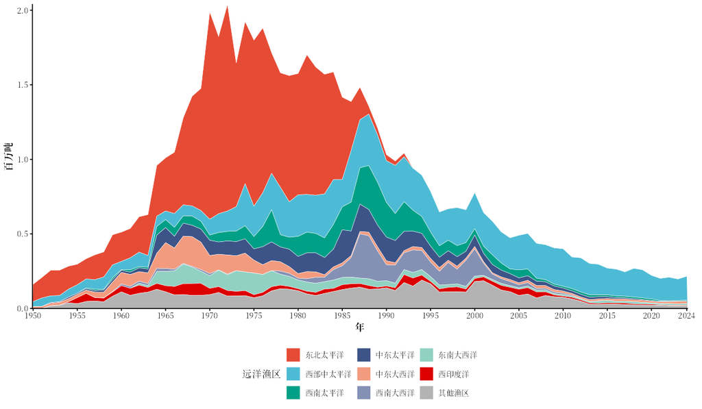

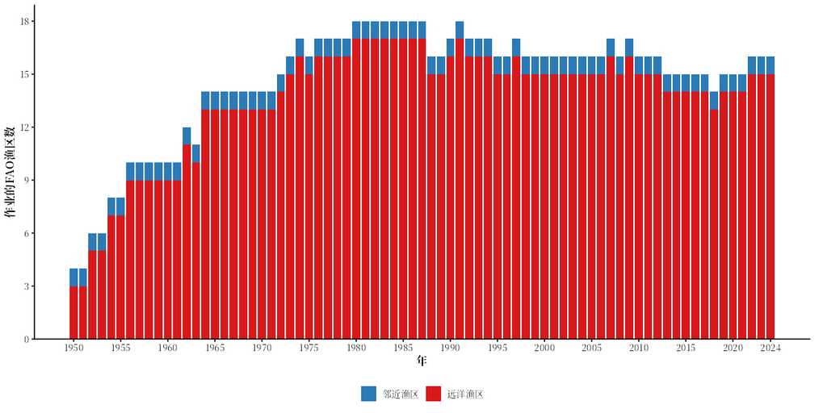

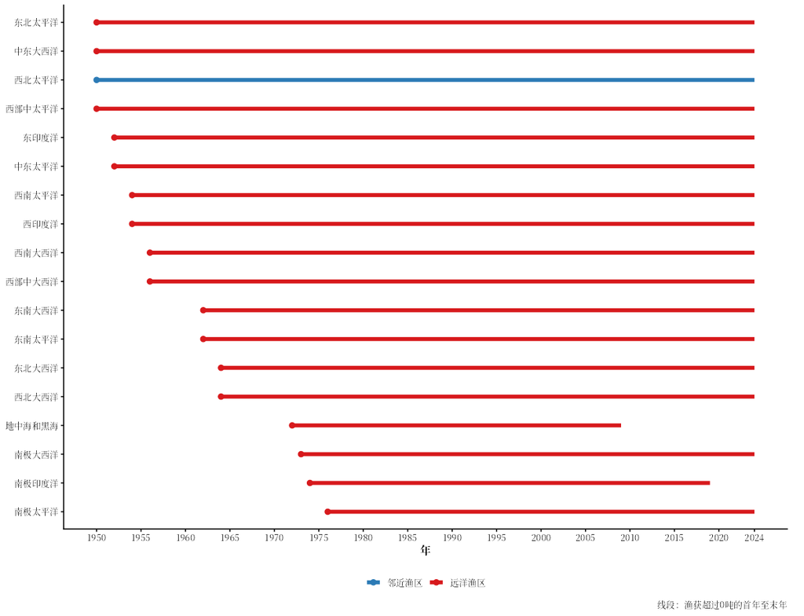

🔎 *怎么看这些图*：一个国家在与其相邻的FAO渔区（“邻近渔区”）和其他渔区（“远洋渔区”）的渔获量、远洋渔获所占的比例、每年作业的渔区数，以及它进入每个渔区的时间（Swartz等，2010）。

*结果*：日本唯一的邻近渔区是61区。它的远洋渔获比例在1970年升到最高的23.1%，当年在13个远洋FAO渔区作业；那一年仅67区就提供了139.1万t，占其远洋渔获的70%。1970年代末的200海里专属区关闭了其中最富饶的水域，2024年这一比例为7.6%。67区和日本展示了同一变化的两个方面。

## 10. 🌡️ 物种特征与温度

### 10.1 FishBase物种特征：`fishbase_match()`

```r
traits <- fishbase_match(area67, version = "builtin")
show_table(traits[, c("species_en", "catch_pct", "match_type", "trophic_level", "temp_pref_mean")], n = 8)
```

| species_en | catch_pct | match_type | trophic_level | temp_pref_mean |
| --- | --- | --- | --- | --- |
| Alaska pollock(=Walleye poll.) | 43.51 | exact | 3.57 | 1.6 |
| North Pacific hake | 7.67 | exact | 4.32 | 8.6 |
| Pacific cod | 6.80 | exact | 3.78 | 2.9 |
| Pink(=Humpback) salmon | 5.25 | exact | 4.49 | 3.3 |
| Pacific herring | 4.61 | exact | 3.16 | 2.8 |
| Sockeye(=Red) salmon | 4.25 | exact | 3.54 | 4.2 |
| Yellowfin sole | 3.42 | exact | 3.49 | 3.4 |
| Pacific ocean perch | 2.66 | exact | 3.48 | 3.8 |

🔎 *怎么看这张表*：每个FAO物种条目按已发表的规则与FishBase或SeaLifeBase匹配（学名完全相同、同物异名、WoRMS、更高分类阶元的平均值）；`match_type`说明用的是哪条规则，每一行都附有核对用的链接。`version = "builtin"`使用本包内置的表格，因此不联网也能运行。匹配结果只是初步结果：请用链接核对主要物种（见🐠 FishBase与SeaLifeBase物种特征）。

### 10.2 海表温度与渔获平均温度

```r
sst67 <- fao_area_sst("Pacific, Northeast")
mtc <- mean_temperature_catch(area67, version = "builtin")
show_table(mtc$trend[, c("period_start", "period_end", "mtc_slope_per_decade", "trend", "sst_slope_per_decade", "cor_mtc_sst")])
```

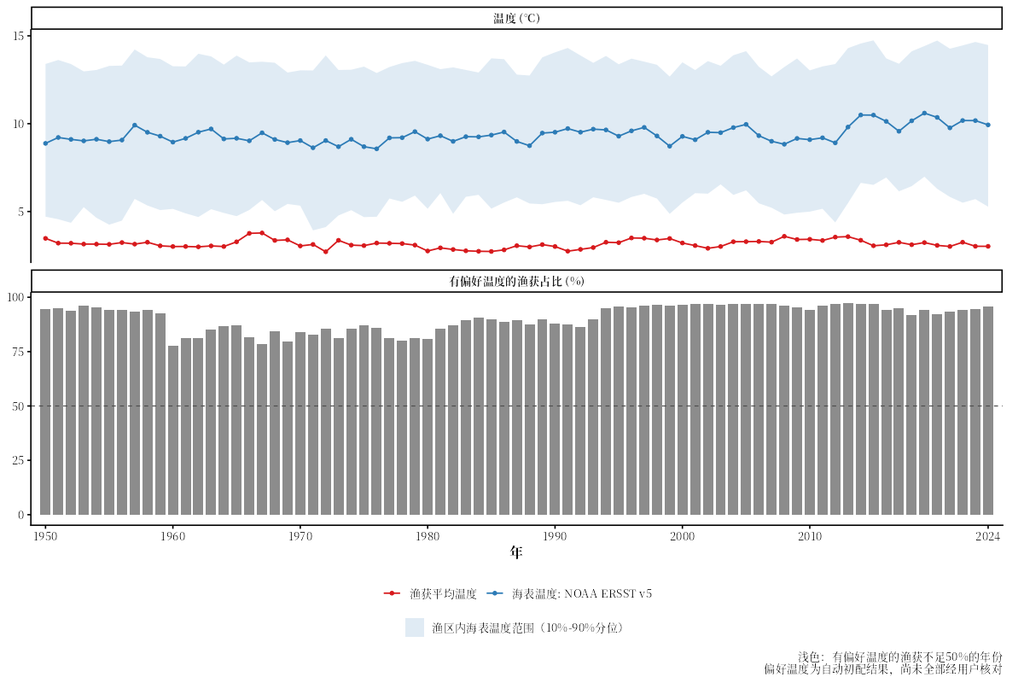

🔎 *怎么看这张图*：**渔获平均温度**（MTC，红线）是渔获物种偏好温度的平均值，按渔获量加权（Cheung等，2013）；蓝线是该渔区的海表温度（SST），浅色带是它在渔区内的范围。下半部分是偏好温度已知的渔获量所占的比例；低于50%的年份淡化显示。MTC上升，说明暖水物种在渔获中所占的比例变大。

*67区的结果*：MTC保持在2.7至3.8 °C之间，远低于该渔区的SST（2024年为9.9 °C）。原因在于物种：主要渔获是生活在近底层的冷水性鱼类，如狭鳕（偏好温度1.6 °C）和太平洋鳕（2.9 °C）。MTC在1972年最低，当年狭鳕占渔获量的52%；在1967年最高，那时狭鳕渔业尚未壮大；美国西海岸的北太平洋无须鳕（8.6 °C）渔获量大的年份会把它拉高。MTC在1950–2024年间的趋势为“无趋势”（每十年0.009 °C），在1970–2024年间为“无趋势”（每十年0.056 °C），同期SST每十年升高0.21 °C。67区的MTC主要反映目标物种的组成，而不是海洋：要结合物种图来看。

## 11. 📉 主要物种的资源评估

`cmsy_area()`对渔获量最大的几个物种运行CMSY++仅渔获量资源评估（Froese等，2023）。它需要先安装一次JAGS程序（`cmsy_setup()`，见📉 CMSY++仅渔获量资源评估），运行需要几分钟；下面的图是事先用同样的代码生成的。

```r
cmsy_setup()                                            # 只需一次：安装JAGS和所需的R包
nep_cmsy <- cmsy_area("Pacific, Northeast", top = 10)   # 十个主要物种
nep_cmsy$summary                                        # B/Bmsy、F/Fmsy、MSY和资源状态
```

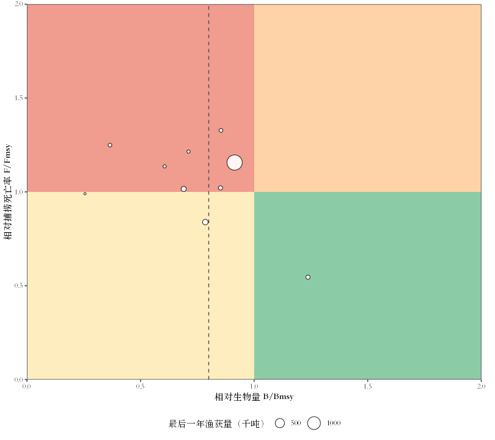

🔎 *怎么看Kobe图*：每个圆圈是一个种群在最后一年的状态：横轴是生物量与产生最大可持续产量的生物量之比（B/Bmsy），纵轴是捕捞压力与产生最大可持续产量的捕捞压力之比（F/Fmsy）；圆圈的大小表示渔获量。绿色（右下）：健康；红色（左上）：已过度捕捞且仍在过度捕捞；橙色和黄色：两者之一。B/Bmsy = 0.8处的虚线，按照FAO对仅渔获量结果的分级，把“最大可持续捕捞”与“过度捕捞”分开。

*67区的结果*：在评估的10个种群中，有6个在最后一年低于0.8 Bmsy；最低的是太平洋鲱（0.26）和Pacific ocean perch（0.37），也就是渔获量离其峰值最远的两个渔业。

| Stock | species | B_Bmsy | F_Fmsy | MSY | status |
| --- | --- | --- | --- | --- | --- |
| ALK_67 | 狭鳕 | 0.91 | 1.16 | 1,382,729 | 最大可持续捕捞 |
| NHA_67 | 北太平洋无须鳕 | 0.69 | 1.02 | 268,082 | 过度捕捞 |
| PCO_67 | 太平洋鳕 | 0.78 | 0.84 | 266,781 | 过度捕捞 |
| PIN_67 | 细鳞大麻哈鱼 | 0.61 | 1.14 | 163,342 | 过度捕捞 |
| HEP_67 | 太平洋鲱 | 0.26 | 0.99 | 197,699 | 过度捕捞 |
| SOC_67 | 红大麻哈鱼 | 0.85 | 1.02 | 134,004 | 最大可持续捕捞 |
| YES_67 | 糙鲽 | 1.24 | 0.55 | 152,488 | 最大可持续捕捞 |
| OPP_67 | Pacific ocean perch | 0.37 | 1.25 | 191,429 | 过度捕捞 |
| CHU_67 | 大麻哈鱼 | 0.71 | 1.21 | 59,817 | 过度捕捞 |
| HUM_67 | 单鳍多线鱼 | 0.85 | 1.33 | 59,732 | 最大可持续捕捞 |

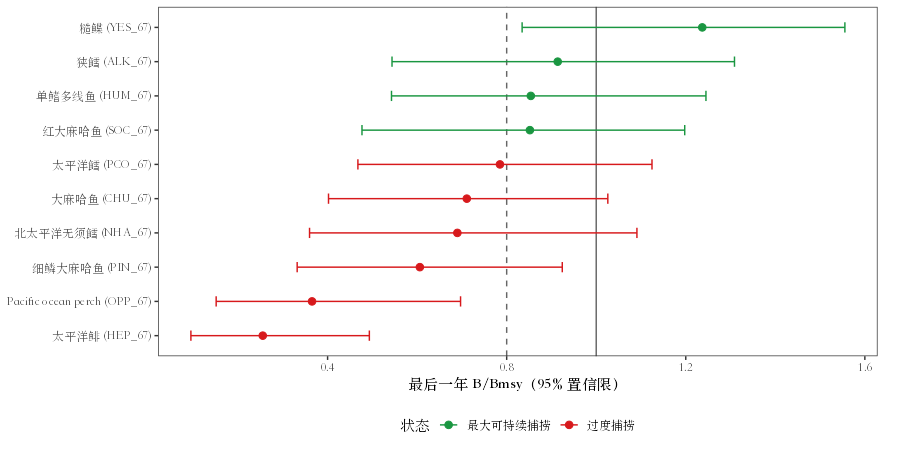

🔎 *怎么看这张图*：每个种群一行：最后一年的B/Bmsy及其95%置信限（横条），颜色表示状态。横条越长，说明数据越难确定该种群的资源量。

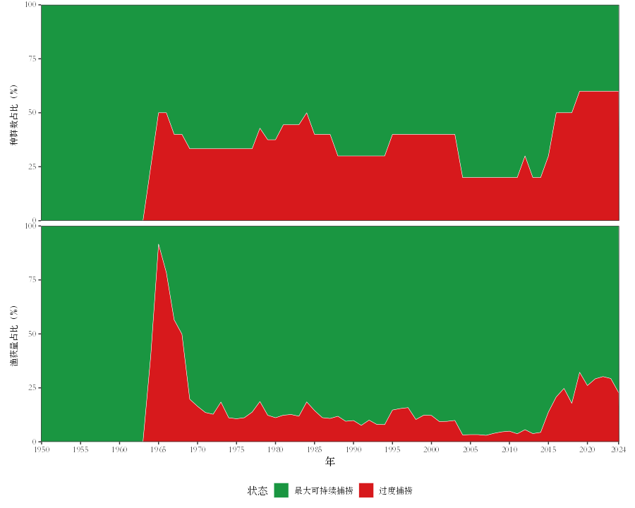

🔎 *怎么看这张图*：逐年各状态类别的种群所占比例，可以看出该渔区的种群是否同步变化，例如是否在同一时期一起下降。

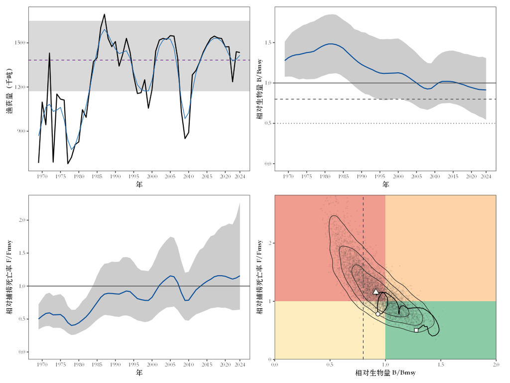

FAO捕捞统计没有丰度指数，所以这些都是**仅渔获量**评估，结果在很大程度上由先验决定：只具有指示意义，绝不能替代完整的资源评估。这一点在67区尤其重要：它的大多数主要种群每年都由美国和加拿大的渔业管理机构利用调查数据进行评估，渔获量受捕捞限额控制，因此一个停留在过去峰值以下的渔获量，可能被仅渔获量方法解读为资源量减少。使用这些结果之前，请与官方评估进行比较。CMSY++的代码来自其作者（https://github.com/SISTA16/cmsyPlusPlus）；见📉 CMSY++仅渔获量资源评估中的免责说明。

## 12. 📝 Word、LaTeX和PDF格式的报告

`fao_report()`运行该渔区的各项分析，把整个评估写成一份报告：封面、摘要、数据与方法、附图表的结果、结论、参考文献和附录。这里生成一份中文Word报告，在默认章节之外加入渔获骤变和渔获平均温度：

```r
report <- fao_report(67, lang = "zh", shocks = TRUE, mtc = TRUE)
report
```

```
#> FAO report: /tmp/Rtmp4BSWgT/faofishingreport_site_2191c2807ca5b/reports/FAO67_report_zh.docx
#> Sections: total, species, countries, groups, status, quality, diversity, fleets, shocks, mtc
#>   $main_species           main species of the last five years (10 rows)
#>   $main_countries         main fishing countries of the last five years (5 rows)
#>   $mtc_species            species of the mean temperature of the catch, with FishBase matches (200 rows)
#>   $analyses               results of the analyses: total, species, countries, groups, status, quality, diversity, fleets, shocks, mtc
```

Word文件的各级标题：

```r
doc <- officer::docx_summary(officer::read_docx(report$file[["docx"]]))
headings <- doc$text[doc$style_name %in% c("FAO Heading 1", "FAO Heading 2")]
headings
```

```
#>  [1] "1 数据来源与分析方法"     "1.1 数据来源"
#>  [3] "1.2 分析方法"             "2 结果与结论"
#>  [5] "2.1 渔获量变化与阶段划分" "2.2 主要渔获种类"
#>  [7] "2.3 主要捕捞国家（地区）" "2.4 渔获类群组成"
#>  [9] "2.5 资源开发状态"         "2.6 数据质量"
#> [11] "2.7 渔获多样性与集中度"   "2.8 沿岸国与远洋捕捞"
#> [13] "2.9 渔获骤变"             "2.10 渔获平均温度"
#> [15] "2.11 结论"                "参考文献"
#> [17] "附件"
```

### 12.1 生成PDF之前：安装一次TinyTeX

Word文件和LaTeX源文件（`format = "latex"`）不需要其他软件。**PDF**由LaTeX源文件用XeLaTeX编译而成，XeLaTeX包含在LaTeX发行版中。最简单的是[TinyTeX](https://yihui.org/tinytex/)（Xie，2019），一个在R中就能安装的小型发行版，不需要管理员权限：

```r
install.packages("tinytex")
tinytex::install_tinytex()   # 只需一次，几分钟；装完后重启R
tinytex::is_tinytex()        # 安装成功时返回TRUE
```

第一次生成PDF会慢一些：TinyTeX会下载报告用到的LaTeX宏包（中文报告需要`ctex`和中文字体等），并保存下来供以后使用。如果TinyTeX是很早以前安装的，生成PDF时出现“TeX Live is older than remote”之类的信息，用`tinytex::reinstall_tinytex()`更新。其他情况（使用其他LaTeX发行版、编译修改过的`.tex`文件）见📝 一键生成评估报告。

### 12.2 同一份报告的LaTeX和PDF版本

同一份中文报告的LaTeX和PDF版本，并加入CMSY++（沿用第11步的结果，不必再次运行CMSY++）：

```r
fao_report(67, lang = "zh", format = c("docx", "latex", "pdf"), shocks = TRUE, mtc = TRUE,
           cmsy = nep_cmsy)
```

| 文件 | 内容 |
| --- | --- |
| `reports/FAO67_report_zh.docx` | Word报告，供编辑和补充 |
| `reports/FAO67_report_zh.tex`和`reports/FAO67_report_zh_figures/` | LaTeX源文件及其图片 |
| `reports/FAO67_report_zh.pdf` | PDF（需要XeLaTeX，例如TinyTeX，见上文） |

报告是一份**初稿**：文字由模板填入分析结果生成。请通读全文，补充灰色的“【待补充：……】”备注（其他数据来源、讨论、其他参考文献），并对照上面的图表核对每一条结论。全部选项见📝 一键生成评估报告（Word、LaTeX、PDF）。

## 13. 🗂️ 文件保存在哪里，如何重新读取

每个函数都把结果写入工作目录：

| 文件夹 | 内容 | 由哪个函数写入 |
| --- | --- | --- |
| `figures/png/` | `fishing_trend.png`、`fishing_percentage.png` | `fishing_area_data()` |
| `figures/png/area/` | `area_species*.png`、`area_country*.png` | `fishing_area_species()`、`fishing_area_country()` |
| `figures/png/` | `area_country_map.png`、`<species>_country_map.png` | `fishing_area_country()`和`species_country()`的地图 |
| `figures/png/species/` | `<species>_country_*.png` | `species_country()` |
| `figures/png/country/` | `<country>_species_*.png`、`<country>analysis_*.png`、`<country>yearly_area_production*.png` | `country_species()`、`country_analysis()` |
| `figures/png/summary/` | `<label>_<analysis>*.png`，如`Pacific__Northeast_stock_status_stocks.png` | 汇总分析和文献方法 |
| `figures/pptx/...` | 同样的图表，保存为PowerPoint文件 | `pptx = TRUE`时 |
| `tables/` | CSV表格（UTF-8编码，可用Excel打开） | 设置`table = TRUE`的所有函数 |
| `reports/` | 报告，以及存放CMSY++结果的`reports/cmsy/` | `fao_report()` |
| `cmsy_areas/` | 各渔区的CMSY++运行结果、图表和表格 | `cmsy_area()` |

本教程保存的文件：

```r
head(list.files("figures/png", recursive = TRUE), 20)
```

```
#>  [1] "Alaska_pollock__Walleye_poll___country_map.png"
#>  [2] "area_country_map.png"
#>  [3] "area/area_country_wrap.png"
#>  [4] "area/area_country.png"
#>  [5] "area/area_species_wrap.png"
#>  [6] "area/area_species.png"
#>  [7] "country/United_States_of_America_species_pie_selected.png"
#>  [8] "country/United_States_of_America_species_ranked_total.png"
#>  [9] "country/United_States_of_America_species_ranked_wrap.png"
#> [10] "country/United_States_of_America_species_ranked.png"
#> [11] "country/United_States_of_Americaanalysis_area_total_production.png"
#> [12] "country/United_States_of_Americaanalysis_species_by_area.png"
#> [13] "country/United_States_of_Americaanalysis_species_pie_selected.png"
#> [14] "country/United_States_of_Americaanalysis_species_ranked_total.png"
#> [15] "country/United_States_of_Americaanalysis_species_ranked_wrap.png"
#> [16] "country/United_States_of_Americaanalysis_species_ranked.png"
#> [17] "country/United_States_of_Americafishing_area_map.png"
#> [18] "country/United_States_of_Americayearly_area_production_wrap.png"
#> [19] "country/United_States_of_Americayearly_area_production.png"
#> [20] "fishing_percentage.png"
```

```r
length(list.files("figures/png", recursive = TRUE))
```

```
#> [1] 65
```

```r
head(list.files("tables"), 10)
```

```
#>  [1] "Alaska_pollock__Walleye_poll___country_ranked_table.csv"
#>  [2] "area67_species_shocks_by_group.csv"
#>  [3] "area67_species_shocks_by_year.csv"
#>  [4] "area67_species_shocks_series.csv"
#>  [5] "area67_species_shocks.csv"
#>  [6] "country_coefs_data.csv"
#>  [7] "country_ranked_table.csv"
#>  [8] "Japan_distant_water_areas.csv"
#>  [9] "Japan_distant_water.csv"
#> [10] "marine_areas_peak_trend_area.csv"
```

**重新读取结果。**每个函数还会把结果返回给R（像上面那样赋值给变量）。要改天接着分析，可以把结果保存下来再读回，或者读取CSV表格：

```r
saveRDS(list(NEP = NEP, status = status, mtc = mtc), "area67_results.rds")
results <- readRDS("area67_results.rds")
names(results)
```

```
#> [1] "NEP"    "status" "mtc"
```

```r
head(read.csv("tables/Pacific__Northeast_stock_status_stocks.csv"), 3)
```

```
#>          species_name                     species_en first_year peak_year
#> 1                狭鳕 Alaska pollock(=Walleye poll.)       1950      1987
#> 2 Pacific ocean perch            Pacific ocean perch       1950      1965
#> 3      北太平洋无须鳕             North Pacific hake       1960      1987
#>   peak_tonnes last_year_tonnes pct_of_peak status_last_year
#> 1     1694473       1434351.99    84.64885         充分开发
#> 2      460647         63974.28    13.88792           恢复中
#> 3      372672        143562.00    38.52235         过度开发
```

FAO发布新版本后，运行`download_fao_data()`，再运行同样的代码：每张图、每个表格和每个数字都会用新数据重新计算，`fao_data_info()`给出新的引用格式。

## 14. 🎨 按需定制

同样的分析可以改用英文或中英双语图表，也可以换一种风格或地图投影：

```r
fao_settings(lang = "en")                  # 英文图表和名称
fao_settings(lang = "both")                # 同一张图上显示中文和英文
fao_settings(theme = "minimal", palette = "npg", map_projection = "robinson", map_center = 180)
fao_settings(reset = TRUE)                 # 恢复默认设置
```

全部设置见🎨 自定义图表与地图。

## ✅ 小结

| 步骤 | 函数 | 主要输出 |
| --- | --- | --- |
| 数据 | `load_fao_data()`、`fao_data_info()` | 数据及需要引用的版本 |
| 渔区 | `fishing_area_data()` | 总渔获量、阶段、占全球的比例 |
| 物种、国家 | `fishing_area_species()`、`fishing_area_country()`、`species_country()`、`country_species()`、`country_analysis()` | 谁捕捞什么，以及各自的阶段 |
| 资源状态 | `species_group_composition()`、`stock_status()`、`peak_trend()`、`regime_shift()`、`area_overview()` | 类群结构、资源状态、趋势、突变 |
| 数据质量、船队 | `data_quality()`、`diversity_concentration()`、`country_group_summary()`、`coastal_distant()` | 数据有多可靠，渔获有多集中 |
| 文献方法 | `catch_shocks()`、`collapse_analysis()`、`catch_synchrony()`、`pelagic_demersal()`、`distant_water_profile()` | 渔获骤变、崩溃、同步性、P/D、远洋船队 |
| 温度 | `fishbase_match()`、`fao_area_sst()`、`mean_temperature_catch()` | 物种特征、SST、MTC |
| 资源评估 | `cmsy_area()` | B/Bmsy、F/Fmsy、MSY |
| 报告 | `fao_report()`，PDF需要TinyTeX | Word、LaTeX、PDF |

## 📖 参考文献

- Bai, J. and Perron, P. (2003). Computation and analysis of multiple structural change models. *Journal of Applied Econometrics*, 18(1), 1–22. [doi:10.1002/jae.659](https://doi.org/10.1002/jae.659)
- Caddy, J. F. (1993). Toward a comparative evaluation of human impacts on fishery ecosystems of enclosed and semi-enclosed seas. *Reviews in Fisheries Science*, 1(1), 57–95. [doi:10.1080/10641269309388535](https://doi.org/10.1080/10641269309388535)
- Cheung, W. W. L., Watson, R. and Pauly, D. (2013). Signature of ocean warming in global fisheries catch. *Nature*, 497, 365–368. [doi:10.1038/nature12156](https://doi.org/10.1038/nature12156)
- Cottrell, R. S., Nash, K. L., Halpern, B. S., Remenyi, T. A., Corney, S. P., Fleming, A., Fulton, E. A., Hornborg, S., Johne, A., Watson, R. A. and Blanchard, J. L. (2019). Food production shocks across land and sea. *Nature Sustainability*, 2, 130–137. [doi:10.1038/s41893-018-0210-1](https://doi.org/10.1038/s41893-018-0210-1)
- de Leiva Moreno, J. I., Agostini, V. N., Caddy, J. F. and Carocci, F. (2000). Is the pelagic-demersal ratio from fishery landings a useful proxy for nutrient availability? *ICES Journal of Marine Science*, 57(4), 1091–1102. [doi:10.1006/jmsc.2000.0705](https://doi.org/10.1006/jmsc.2000.0705)
- FAO. 2026. Global Capture Production 1950-2024, release 2026.1.0. In: Fisheries and Aquaculture [online]. Rome. [Cited 10 October 2026]. https://www.fao.org/fishery/collection/capture/en. Licence: CC BY 4.0.
- Fishery Conservation and Management Act of 1976. Public Law 94-265, 90 Stat. 331, United States (in force 1 March 1977; now the Magnuson-Stevens Fishery Conservation and Management Act).
- Froese, R., Winker, H., Coro, G., Palomares, M. L. D., Tsikliras, A. C., Dimarchopoulou, D., Touloumis, K., Demirel, N., Vianna, G. M. S., Scarcella, G., Schijns, R., Liang, C. and Pauly, D. (2023). New developments in the analysis of catch time series as the basis for fish stock assessments: the CMSY++ method. *Acta Ichthyologica et Piscatoria*, 53, 173–189. [doi:10.3897/aiep.53.105910](https://doi.org/10.3897/aiep.53.105910)
- Hare, S. R. and Mantua, N. J. (2000). Empirical evidence for North Pacific regime shifts in 1977 and 1989. *Progress in Oceanography*, 47(2–4), 103–145. doi:10.1016/S0079-6611(00)00033-1
- Kleisner, K., Zeller, D., Froese, R. and Pauly, D. (2013). Using global catch data for inferences on the world’s marine fisheries. *Fish and Fisheries*, 14(3), 293–311. [doi:10.1111/j.1467-2979.2012.00469.x](https://doi.org/10.1111/j.1467-2979.2012.00469.x)
- Loreau, M. and de Mazancourt, C. (2008). Species synchrony and its drivers: neutral and nonneutral community dynamics in fluctuating environments. *The American Naturalist*, 172(2), E48–E66. [doi:10.1086/589746](https://doi.org/10.1086/589746)
- Mullon, C., Fréon, P. and Cury, P. (2005). The dynamics of collapse in world fisheries. *Fish and Fisheries*, 6(2), 111–120. [doi:10.1111/j.1467-2979.2005.00181.x](https://doi.org/10.1111/j.1467-2979.2005.00181.x)
- Swartz, W., Sala, E., Tracey, S., Watson, R. and Pauly, D. (2010). The spatial expansion and ecological footprint of fisheries (1950 to present). *PLoS ONE*, 5(12), e15143. [doi:10.1371/journal.pone.0015143](https://doi.org/10.1371/journal.pone.0015143)
- Wilberg, M. J. and Miller, T. J. (2007). Comment on “Impacts of biodiversity loss on ocean ecosystem services”. *Science*, 316, 1285. [doi:10.1126/science.1137946](https://doi.org/10.1126/science.1137946)
- Xie, Y. (2019). TinyTeX: a lightweight, cross-platform, and easy-to-maintain LaTeX distribution based on TeX Live. *TUGboat*, 40(1), 30–32. https://tug.org/TUGboat/tb40-1/tb124xie-tinytex.pdf; R package tinytex: https://CRAN.R-project.org/package=tinytex